# Simpson-Style Example of Context-Dependent Correlation

Kevin R. Coombes (analysis extended by Amir)

Original: 1 January 2026; Latest Run: 2026-01-05

# Summary

We want a concrete Simpson-style example: a miR-mRNA pair whose *global* correlation has the opposite sign of the *majority* of within-cohort correlations. We searched the top 10 high-variance miRs and ranked pairs by spread plus sign reversal. The best pair is **hsa-miR-200c-3p vs HTRA3** with global correlation **+0.403**, but **22** cohorts are negative vs **9** positive (31 valid). The cohort spread is **1.178** and median |r| is **0.272**; the most positive cohort is **UVM (r = 0.555)** and the most negative is **READ (r = -0.623)**. We then visualize this in global and cohort-specific plots, add a filtered Simpson-style view that removes low-|r| cohorts, and quantify the heterogeneity with Cochran’s Q/I² plus a random-effects meta-analysis of Fisher Z values.

# Background

The global (pan-cancer) correlation can be dominated by differences between cohorts. To illustrate this clearly, we will identify a miR-mRNA pair with a strong correlation across all samples, but an opposite pattern when we compute the correlations within each cancer cohort.

# Data and Setup

Rationale: we load the matched miR/mRNA expression data and validate that cohort labels and colors are available for plotting.

```r
source("00-paths.R")
f1 <- file.path(paths$mirtcga, "matchedNoGBM.Rda")
f2 <- file.path(paths$mirtcga, "matchedNoGBM.rda")
if (file.exists(f1)) {
  load(f1)
} else if (file.exists(f2)) {
  load(f2)
} else {
  stop("Cannot find matchedNoGBM.Rda or matchedNoGBM.rda in ", paths$mirtcga)
}
rm(paths)
if (!exists("cohortColors")) {
  stop("cohortColors not found in matchedNoGBM data.")
}
if (!exists("colvec")) {
  colvec <- cohortColors[cancerType]
}
dim(miRdata)
```

```
## [1] 1146 8890
```

```r
dim(mRNAdata)
```

```
## [1] 20289  8890
```

```r
length(cancerType)
```

```
## [1] 8890
```

The matched data load cleanly. Next, we will confirm sample sizes per cohort to guide thresholds for the local correlation analysis.

Rationale: we want to understand cohort sizes so we can avoid tiny cohorts when we screen for sign flips.

```r
nPerCohort <- sort(table(cancerType), decreasing = TRUE)
nPerCohort
```

```
## cancerType
## BRCA THCA PRAD  LGG HNSC LUAD SKCM BLCA LIHC STAD LUSC KIRC KIRP CESC   OV SARC COAD UCEC ESCA
##  847  567  546  526  524  469  451  424  419  405  380  326  323  309  291  261  221  197  195
## PCPG PAAD TGCT THYM KICH MESO  UVM  ACC READ  UCS DLBC CHOL
##  187  183  156  122   91   87   80   79   76   56   47   45
```

```r
summary(as.vector(nPerCohort))
```

```
##    Min. 1st Qu.  Median    Mean 3rd Qu.    Max.
##    45.0   106.5   261.0   286.8   421.5   847.0
```

Most cohorts have large sample sizes, so we can safely require a minimum number of cohorts with non-missing correlations. Next, we choose a small set of miRs to screen based on variance across all samples.

# Search Strategy

Rationale: we start with miRs that vary the most across the full data set, because they are more likely to produce strong, interpretable correlations.

```r
mirVar <- apply(miRdata, 1, var)
mirRank <- names(sort(mirVar, decreasing = TRUE))
topN <- 10
topMir <- mirRank[1:topN]
topMir
```

```
##  [1] "hsa-miR-205-5p"  "hsa-miR-375"     "hsa-miR-200c-3p" "hsa-miR-141-3p"  "hsa-miR-141-5p"
##  [6] "hsa-miR-203a-3p" "hsa-miR-1269a"   "hsa-miR-9-5p"    "hsa-miR-200b-3p" "hsa-miR-200a-5p"
```

We now evaluate each of these miRs for a Simpson-style pattern by comparing global correlations to the sign pattern across cohorts.

Rationale: for each candidate miR, we compute global correlations to all genes, then compute within-cohort correlations and look for sign reversals with large spread.

```r
minCohorts <- 10
minOppCount <- 10
minMedianAbs <- 0.25
minGlobalAbs <- 0.20

candidateList <- list()
for (mir in topMir) {
  mAll <- miRdata[mir, ]
  global <- cor(t(mRNAdata), mAll)
  local <- sapply(levels(cancerType), function(ct) {
    idx <- which(cancerType == ct)
    cor(t(mRNAdata[, idx]), mAll[idx])
  })
  nValid <- rowSums(!is.na(local))
  nPos <- rowSums(local > 0, na.rm = TRUE)
  nNeg <- rowSums(local < 0, na.rm = TRUE)
  medAbs <- apply(local, 1, function(x) median(abs(x), na.rm = TRUE))
  spread <- apply(local, 1, function(x) max(x, na.rm = TRUE) - min(x, na.rm = TRUE))

  oppCount <- ifelse(global > 0, nNeg, nPos)
  majOpp <- oppCount > (nValid / 2)
  flip <- !is.na(global) & nValid >= minCohorts &
    oppCount >= minOppCount & majOpp &
    medAbs >= minMedianAbs & abs(global) >= minGlobalAbs

  if (any(flip)) {
    score <- spread * abs(global)
    score[!flip] <- NA
    pick <- which.max(score)
    candidateList[[mir]] <- data.frame(
      miR = mir,
      gene = rownames(mRNAdata)[pick],
      global = global[pick],
      spread = spread[pick],
      nPos = nPos[pick],
      nNeg = nNeg[pick],
      nValid = nValid[pick],
      medAbs = medAbs[pick],
      score = score[pick],
      stringsAsFactors = FALSE
    )
  }
}
```

[output not shown]

[output not shown]

[output not shown]

[output not shown]

[output not shown]

[output not shown]

[output not shown]

[output not shown]

[output not shown]

[output not shown]

```r
candidates <- do.call(rbind, candidateList)
candidates <- candidates[order(-candidates$score), ]
head(candidates, 5)
```

```
##                             miR  gene    global    spread nPos nNeg nValid    medAbs     score
## hsa-miR-200c-3p hsa-miR-200c-3p HTRA3 0.4033392 1.1781247    9   22     31 0.2721521 0.4751839
## hsa-miR-141-5p   hsa-miR-141-5p LTBP2 0.4576629 0.9958472   12   19     31 0.2810867 0.4557623
## hsa-miR-141-3p   hsa-miR-141-3p   LUM 0.4195366 1.0473584   11   20     31 0.2712072 0.4394052
## hsa-miR-200b-3p hsa-miR-200b-3p HTRA3 0.2950696 1.3136332   10   21     31 0.3187067 0.3876132
## hsa-miR-200a-5p hsa-miR-200a-5p HTRA3 0.3149874 1.2099256   11   20     31 0.3072315 0.3811114
```

We identified one or more strong candidates. Next, we select the top-ranked pair and compute the full cohort-wise correlation profile for visualization.

# Detailed Look at the Best Pair

Rationale: we recompute cohort correlations for the top-ranked pair and extract the most extreme positive and negative cohorts for focused plots.

```r
best <- candidates[1, ]
bestMir <- best$miR
bestGene <- best$gene

mAll <- miRdata[bestMir, ]
globalBest <- cor(mRNAdata[bestGene, ], mAll)
localBest <- sapply(levels(cancerType), function(ct) {
  idx <- which(cancerType == ct)
  cor(mRNAdata[bestGene, idx], mAll[idx])
})
nPerCohort <- table(cancerType)
localTab <- data.frame(
  Cohort = names(localBest),
  Correlation = as.vector(localBest),
  N = as.vector(nPerCohort[names(localBest)]),
  stringsAsFactors = FALSE
)
localTab <- localTab[order(localTab$Correlation, decreasing = TRUE), ]
localTab
```

```
##    Cohort Correlation   N
## 31    UVM  0.55524312  80
## 26   TGCT  0.44587707 156
## 12   KIRP  0.41065589 323
## 14   LIHC  0.35654055 419
## 1     ACC  0.33701292  79
## 13    LGG  0.29563512 526
## 17   MESO  0.14538103  87
## 24   SKCM  0.14323897 451
## 5    CHOL  0.06828358  45
## 28   THYM -0.02961634 122
## 20   PCPG -0.05519068 187
## 23   SARC -0.05789317 261
## 19   PAAD -0.20566030 183
## 9    HNSC -0.22683529 524
```

[output cut: 17 more lines]

The top-ranked pair shows clear sign disagreement: the global correlation has the opposite sign from most cohorts. Now we will visualize this in three steps: (1) global scatter, (2) cohort correlation bars, and (3) two contrasting cohorts.

Rationale: the global scatter plot shows the overall correlation across all samples.

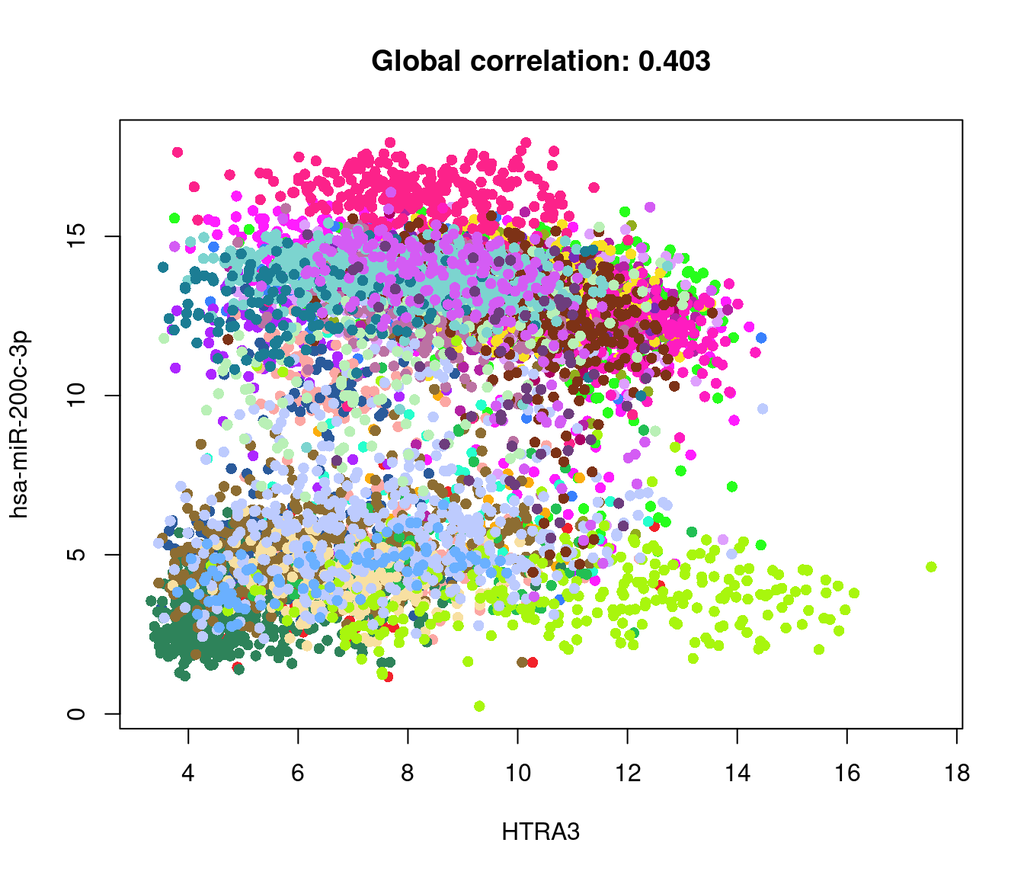

Figure 1 : Global miR-mRNA correlation across all cohorts.

```r
plot(mRNAdata[bestGene, ], mAll, col = colvec, pch = 16,
     xlab = bestGene, ylab = bestMir,
     main = paste("Global correlation:", round(globalBest, 3)))
```

The global scatter highlights a clear overall trend. Next, we compare it to the cohort-by-cohort correlations to show the contradiction explicitly.

Rationale: a barplot of cohort correlations makes the sign reversal easy to read.

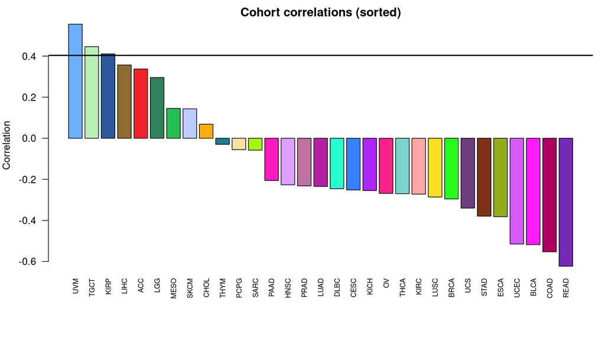

Figure 2 : Within-cohort correlations for the Simpson-style pair.

```r
opar <- par(mar = c(8, 4, 2, 1))
pts <- barplot(localTab$Correlation, names.arg = localTab$Cohort,
               col = cohortColors[localTab$Cohort], las = 2, cex.names = 0.7,
               ylab = "Correlation", main = "Cohort correlations (sorted)")
abline(h = globalBest, lwd = 2, col = "black")
```

```r
par(opar)
```

The barplot shows the mismatch between the global estimate and the local pattern. Next, we inspect one positive and one negative cohort in detail.

Rationale: contrasting two cohorts makes the Simpson-style reversal concrete in raw expression space.

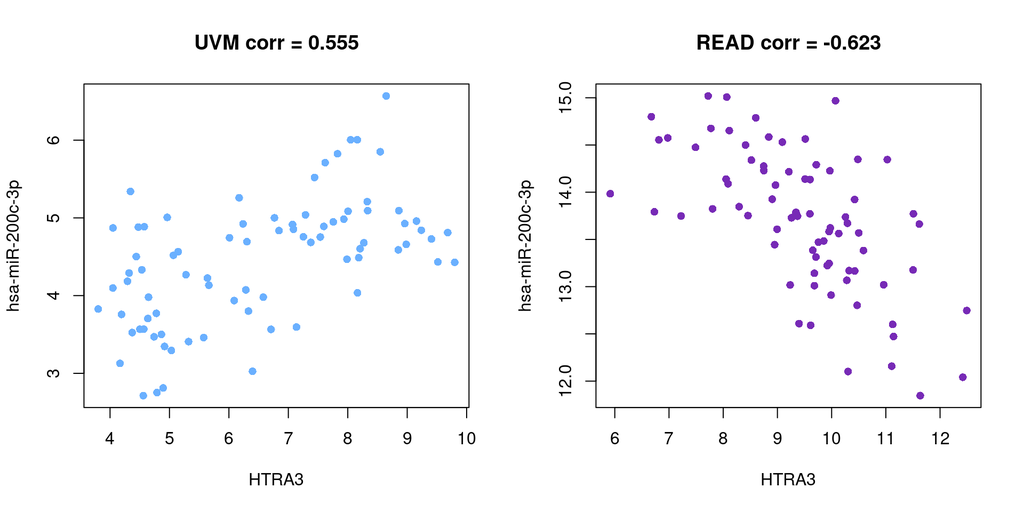

Figure 3 : Contrasting cohorts with opposite-sign correlations.

```r
posCohort <- localTab$Cohort[1]
negCohort <- localTab$Cohort[nrow(localTab)]

par(mfrow = c(1,2))
idxPos <- which(cancerType == posCohort)
plot(mRNAdata[bestGene, idxPos], mAll[idxPos], col = cohortColors[posCohort], pch = 16,
     xlab = bestGene, ylab = bestMir,
     main = paste(posCohort, "corr =", round(localBest[posCohort], 3)))

idxNeg <- which(cancerType == negCohort)
plot(mRNAdata[bestGene, idxNeg], mAll[idxNeg], col = cohortColors[negCohort], pch = 16,
     xlab = bestGene, ylab = bestMir,
     main = paste(negCohort, "corr =", round(localBest[negCohort], 3)))
```

```r
par(mfrow = c(1,1))
```

The two cohort plots show opposite slopes, confirming that the global correlation is not representative of most cohort-level relationships. Next, we will report a short table of sign counts to make the logic explicit.

Rationale: a compact table summarizes the sign distribution across cohorts.

```r
signSummary <- data.frame(
  Global = globalBest,
  N_Pos = sum(localBest > 0, na.rm = TRUE),
  N_Neg = sum(localBest < 0, na.rm = TRUE),
  N_Valid = sum(!is.na(localBest)),
  Median_Abs = median(abs(localBest), na.rm = TRUE)
)
signSummary
```

```
##      Global N_Pos N_Neg N_Valid Median_Abs
## 1 0.4033392     9    22      31  0.2721521
```

This summary confirms that the global sign is opposite to the majority of cohort signs, which is the core Simpson-style effect we wanted. At this point, we have a concrete example and three linked figures suitable for a manuscript or supplement.

# Decomposition: Between vs Within Cohorts

Rationale: quantify how much of the global correlation is driven by between-cohort differences versus within-cohort covariance.

```r
coh <- as.character(cancerType)
mx <- tapply(mRNAdata[bestGene, ], coh, mean)
my <- tapply(mAll, coh, mean)

N <- length(mAll)
muX <- mean(mRNAdata[bestGene, ])
muY <- mean(mAll)

covGlobal <- cov(mRNAdata[bestGene, ], mAll)
covWithin <- 0
covBetween <- 0
for (ct in names(mx)) {
  idx <- which(cancerType == ct)
  nx <- length(idx)
  if (nx < 2) next
  cx <- mRNAdata[bestGene, idx]
  cy <- mAll[idx]
  covWithin <- covWithin + (nx - 1) * cov(cx, cy)
  covBetween <- covBetween + nx * (mean(cx) - muX) * (mean(cy) - muY)
}
covWithin <- covWithin/(N - 1)
covBetween <- covBetween/(N - 1)

data.frame(Global = covGlobal, Within = covWithin, Between = covBetween)
```

```
##     Global     Within  Between
## 1 3.947739 -0.2663189 4.214058
```

The between-cohort covariance is strongly positive, while the within-cohort covariance is negative. This is the quantitative driver of the Simpson reversal.

# Heterogeneity Test (Cochran’s Q, I²)

Rationale: test whether the cohort-specific correlations are statistically consistent with a single common correlation. The null hypothesis is that all cohorts share the same true correlation. The p-value is the chi-squared test for heterogeneity.

```r
nPer <- table(cancerType)
validCoh <- names(localBest)[!is.na(localBest)]
nCoh <- as.numeric(nPer[validCoh])
z <- atanh(localBest[validCoh])
w <- nCoh - 3
zbar <- sum(w * z)/sum(w)

Q <- sum(w * (z - zbar)^2)
df <- length(z) - 1
pval <- 1 - pchisq(Q, df)
I2 <- max(0, (Q - df)/Q)

data.frame(Q = Q, df = df, p_value = pval, I2 = I2)
```

```
##          Q df p_value        I2
## 1 797.7138 30       0 0.9623925
```

The Q test evaluates heterogeneity of Fisher Z across cohorts. A small p-value indicates that the cohort correlations are not equal, supporting context dependence.

# Random-Effects Meta-Analysis of Correlations

Rationale: compute a pooled correlation that allows between-cohort variance (tau²) using a standard DerSimonian–Laird random-effects model on Fisher Z values.

```r
denom <- sum(w) - sum(w^2)/sum(w)
tau2 <- max(0, (Q - df)/denom)

wRE <- 1/(1/w + tau2)
zRE <- sum(wRE * z)/sum(wRE)
rRE <- (exp(2 * zRE) - 1)/(exp(2 * zRE) + 1)

data.frame(tau2 = tau2, zRE = zRE, rRE = rRE)
```

```
##         tau2        zRE        rRE
## 1 0.09159754 -0.1302787 -0.1295466
```

The random-effects estimate reflects the average cohort correlation while accounting for between-cohort heterogeneity.

# Canonical Simpson Visualization (Cohort Means)

Rationale: show the cohort-mean trend directly (Simpson-style).

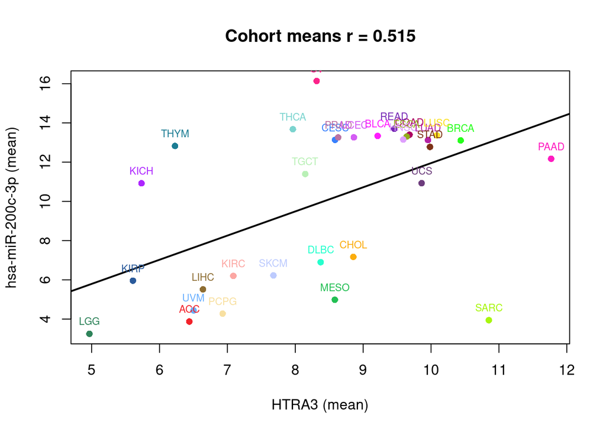

Figure 5 : Cohort means for the Simpson pair.

```r
plot(mx, my, col = cohortColors[names(mx)], pch = 16,
     xlab = paste(bestGene, "(mean)"), ylab = paste(bestMir, "(mean)"),
     main = paste("Cohort means r =", round(cor(mx, my), 3)))
abline(lm(my ~ mx), lwd = 2)
text(mx, my, labels = names(mx), col = cohortColors[names(mx)],
     pos = 3, cex = 0.7)
```

The cohort means show a strong positive trend, even though most within-cohort correlations are negative.

# Filtered Simpson-Style Visualization

Rationale: to sharpen the visual contrast, we keep only the top K cohorts by |r| and overlay the global trend against per-cohort trends for those groups.

```r
K <- 5
ord <- order(abs(localTab$Correlation), decreasing = TRUE)
keep <- localTab$Cohort[ord[1:K]]
keep
```

```
## [1] "READ" "UVM"  "COAD" "BLCA" "UCEC"
```

These cohorts have the strongest within-cohort signals and are best suited for a clean Simpson-style visualization. Next we plot all points in light gray, then overlay the selected cohorts with their own regression lines and the global line.

Rationale: the global line should slope one way, while most cohort lines slope the other way.

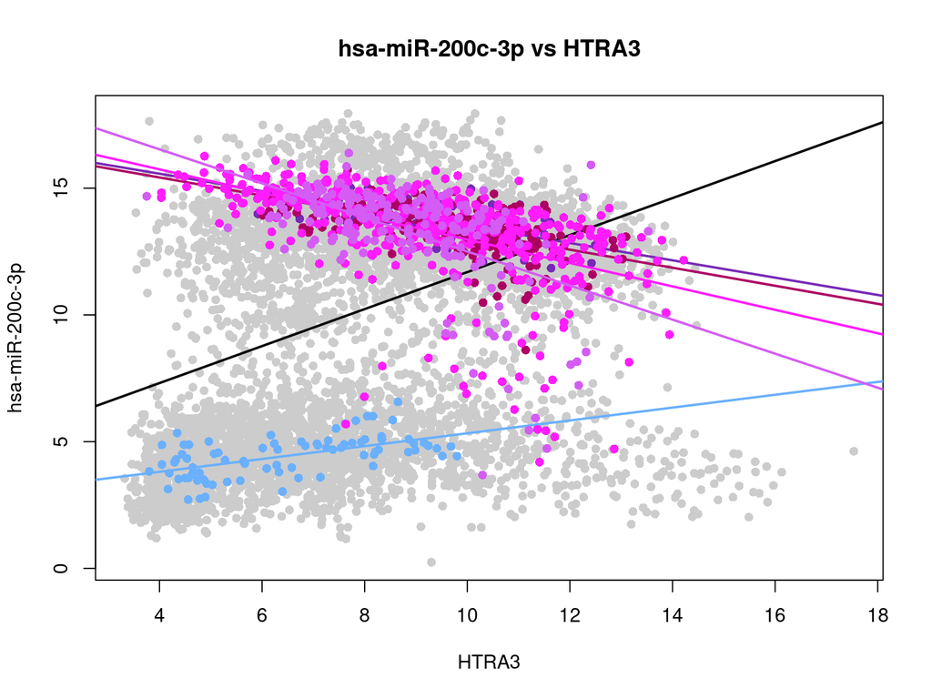

Figure 4 : Simpson-style visualization using filtered cohorts. Gray = all samples, colored = selected cohorts; black line = global trend; colored lines = within-cohort trends.

```r
plot(mRNAdata[bestGene, ], mAll, col = "gray80", pch = 16,
     xlab = bestGene, ylab = bestMir,
     main = paste(bestMir, "vs", bestGene))
abline(lm(mAll ~ mRNAdata[bestGene, ]), lwd = 2)

for (ct in keep) {
  idx <- which(cancerType == ct)
  points(mRNAdata[bestGene, idx], mAll[idx], col = cohortColors[ct], pch = 16)
  abline(lm(mAll[idx] ~ mRNAdata[bestGene, idx]), col = cohortColors[ct], lwd = 2)
}
```

The global line (black) now contrasts clearly with the majority of cohort lines, which highlights the Simpson-style reversal in a single panel.

# Four-Panel Summary Figure

Rationale: combine the key plots into a single multi-panel figure for the main text.

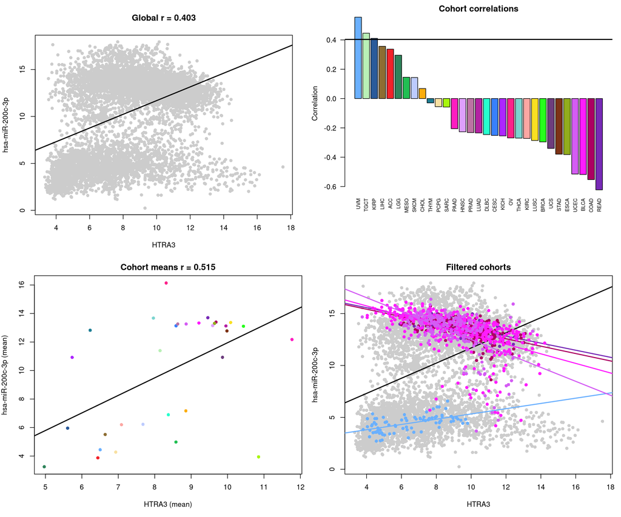

Figure 6 : Four-panel summary of Simpson-style behavior.

```r
opar <- par(mfrow = c(2, 2))

# Panel A: global scatter
plot(mRNAdata[bestGene, ], mAll, col = "gray80", pch = 16,
     xlab = bestGene, ylab = bestMir,
     main = paste("Global r =", round(globalBest, 3)))
abline(lm(mAll ~ mRNAdata[bestGene, ]), lwd = 2)

# Panel B: cohort correlations (barplot)
par(mar = c(8, 4, 2, 1))
barplot(localTab$Correlation, names.arg = localTab$Cohort,
        col = cohortColors[localTab$Cohort], las = 2, cex.names = 0.7,
        ylab = "Correlation", main = "Cohort correlations")
abline(h = globalBest, lwd = 2, col = "black")

# Panel C: cohort means
par(mar = c(5, 4, 2, 1))
plot(mx, my, col = cohortColors[names(mx)], pch = 16,
     xlab = paste(bestGene, "(mean)"), ylab = paste(bestMir, "(mean)"),
     main = paste("Cohort means r =", round(cor(mx, my), 3)))
abline(lm(my ~ mx), lwd = 2)

# Panel D: filtered Simpson plot
plot(mRNAdata[bestGene, ], mAll, col = "gray80", pch = 16,
     xlab = bestGene, ylab = bestMir,
     main = "Filtered cohorts")
abline(lm(mAll ~ mRNAdata[bestGene, ]), lwd = 2)
for (ct in keep) {
  idx <- which(cancerType == ct)
  points(mRNAdata[bestGene, idx], mAll[idx], col = cohortColors[ct], pch = 16)
  abline(lm(mAll[idx] ~ mRNAdata[bestGene, idx]), col = cohortColors[ct], lwd = 2)
}
```

```r
par(opar)
```

This combined figure captures the global trend, cohort variability, mean-level Simpson structure, and the filtered reversal in one place.

# Conclusions

We isolated a single miR-mRNA pair where the global correlation reverses the direction of the majority of cohort-specific correlations. This provides a concrete and visual illustration of why subgroup structure can invalidate naive interpretations of pan-cancer correlation.